# Stick-breaking constructions for mixture and factor models

Simon Dirmeier

August 2021

In this notebook, we will explore fitting a non-parameteric mixture and factor models via stick-breaking constructions. Both of these methods are traditionally fit via slice sampling or Gibbs sampling, but recent developments in probabilistic programming languages are allowing us to fit them easily via automated variational inference (or HMC). While Dirichlet process mixture models (DPMMs) are found frequently in the literature, factor models using the Indian Buffet process (IBP) have received less attention.

On a personal note, I have long been enthusiastic about nonparametric Bayesian models but, except for GPs, have found them hard to work with in practice (at least for principled statistical data analysis). Especially Hamiltonian Monte Carlo samplers, where the simulated trajectories often divergence even for “easy” data sets, seem to be not very suited for this class of models, so I am curious of the results of this study.

We implement the models and variational surrogates using [Numpyro](http://num.pyro.ai/en/latest/index.html). Feedback and comments are welcome!

We load some libraries for inference and working with data first.

```python
import pandas as pd

import jax
import jax.numpy as np
import jax.scipy as sp
import jax.random as random

import numpyro
import numpyro.distributions as dist
import numpyro.distributions.constraints as constraints
from numpyro.distributions.transforms import OrderedTransform
from numpyro.infer import SVI, Trace_ELBO, TraceGraph_ELBO
import numpyro.optim as optim

import tensorflow_probability.substrates.jax.distributions as tfp_jax

import matplotlib.pyplot as plt
import seaborn as sns
import arviz as az
import palettes

palettes.set_theme()
numpyro.set_host_device_count(4)
```

Check if JAX recognizes the four set cores.

```python
jax.local_device_count()
```

```
4
```

# Infinite mixture models

Nonparametric Bayesian mixture models implement a observation model that consists of infinitely many component distributions. Using the stick-breaking construction of a Dirichlet process (Ghosal and Van der Vaart (2017), Blei and Jordan (2006)), the generative model we assume here has the following form

$$\begin{align}
\beta & \sim \text{Gamma}(1.0, 1.0) \\
\nu_k & \sim\text{Beta}(1.0, \beta) \\
\pi_k & \sim \nu_k \prod_{j=1}^{k-1} (1 - \nu_j) \\
\mu_k & \sim \text{Normal}(0.0, 1.0)\\
\sigma_k & \sim \text{Normal}^+(1.0) \\
y_i & \sim \sum_k^{\infty} \pi_k \text{Normal}(\mu_k, \sigma_k)
\end{align}$$

where we truncate $K$ to a sufficiently high value.

## Data

We begin by simulating a data set consisting of three components and 1000 samples. The simulated data set should be fairly easy to fit, real world data is usually significantly more noisy.

```python
n_samples = 1000
K = 3

means = np.linspace(-2.0, 2.0, K)
standard_deviations = np.array([0.25, 0.2, 0.3])

Z = random.randint(
    key=random.PRNGKey(23),
    minval=0,
    maxval=K,
    shape=(n_samples,)
)

eps = dist.Normal(0.0, 1.0).sample(
    random.PRNGKey(23),
    sample_shape=(n_samples,)
)
y = means[Z] + eps * standard_deviations[Z]
```

The three components are centered around $-2$, $0$ and $2$ with a low standard deviation.

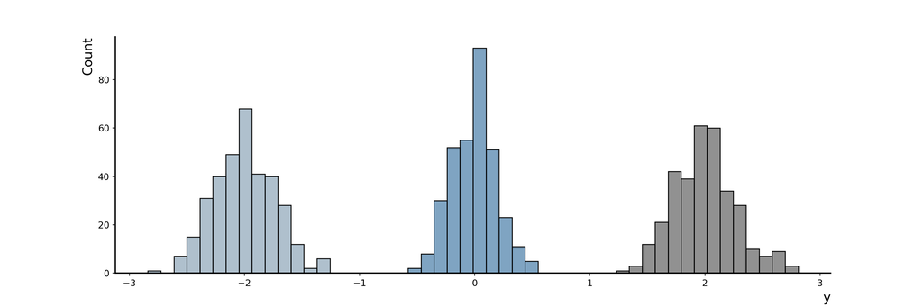

```python
df = pd.DataFrame(np.vstack([y, Z]).T, columns=["y", "z"])
_ = plt.figure(figsize=(15, 5))
sns.histplot(
    x="y",
    hue="z",
    data=df,
    palette=palettes.discrete_sequential_colors(),
    legend=False,
    bins=50,
)
plt.show()
```

## Model

We will truncate the stick at a sufficiently large ($K$, the error of this truncation is, as I believe to recall from a reference I cannot find anymore, negligible).

```python
K_stick = 10
```

Next we defined a routine to compute the mixing weights $\pi$ from $\nu$

```python
def sample_stick(nu):
    ones = np.ones((*nu.shape[:-1], 1))
    rem = np.concatenate(
      [ones, np.cumprod(1 - nu, axis=-1)[:-1]],
      axis=-1
    )
    mix_probs = nu * rem
    return mix_probs
```

We will infer the posterior distributions over the latent variables using the marginal mixture representation above. We define the prior model first. In comparison to the generative model defined above, we will order the mean variables.

```python
def prior():
    beta = numpyro.sample("beta", dist.Gamma(1.0, 1.0))
    nu = numpyro.sample(
        "nu",
        dist.Beta(
          concentration1=np.ones(K_stick),
          concentration0=beta
        )
    )
    pi = numpyro.deterministic("pi", sample_stick(nu))
    mu = numpyro.sample(
        "mu",
        dist.TransformedDistribution(
            dist.Normal(loc=np.zeros(K_stick)),
            OrderedTransform()
        ),
    )
    sigma = numpyro.sample("sigma", dist.HalfNormal(scale=np.ones(K_stick)))

    return pi, mu, sigma
```

We then define the log-likelihood function:

```python
def log_likelihood(y, pi, mu, sigma):
    lpdf_weights = np.log(pi)
    lpdf_components = dist.Normal(loc=mu, scale=sigma).log_prob(
        y[:, np.newaxis]
    )

    lpdf = lpdf_weights + lpdf_components
    lpdf = sp.special.logsumexp(lpdf, axis=-1)
    return np.sum(lpdf)
```

To test the implementation, we can make a draw from the prior and plug it into the likelihood.

```python
with numpyro.handlers.seed(rng_seed=23):
    pi, mu, sigma = prior()

log_likelihood(y, pi, mu, sigma)
```

```
DeviceArray(-4293.6284, dtype=float32)
```

The NumPyro model itself is then only a two-liner. We include the likelihood term using a `factor` in the model specification.

```python
def model():
    pi, mu, sigma = prior()
    numpyro.factor("log_likelihood", log_likelihood(y, pi, mu, sigma))
```

We approximate the posterior distributions using mean field variational inference which requires us to define surrogate distributions for each of the latent variables. Specifically, we will use the following variational surrogates, adopting from Blei and Jordan (2006):

$$\begin{align}
q_{\lambda}(\beta) & = \text{Gamma}(\lambda_{\beta_0}, \lambda_{\beta_1}) \\
q_{\lambda}(\nu_k) & = \text{Beta}(\lambda_{\nu_{k0}}, \lambda_{\nu_{k1}}) \\
q_{\lambda}(\mu_k)_ & = \text{Normal}(\lambda_{\mu_{k0}}, \lambda_{\mu_{k1}}) \\
q_{\lambda}(\sigma_k) & = \text{Normal}^+(\lambda_{\sigma_{k}})\\
\end{align}$$

where we constraint the scale parameters to be positive and the vector $\mu$ to be ordered.

```python
def guide():
    q_beta_concentration = numpyro.param(
        "beta_concentration", init_value=1.0, constraint=constraints.positive
    )
    q_beta_rate = numpyro.param(
        "beta_rate", init_value=1.0, constraint=constraints.positive
    )
    q_beta = numpyro.sample(
        "beta", dist.Gamma(q_beta_concentration, q_beta_rate)
    )

    q_nu_concentration1 = numpyro.param(
        "nu_concentration1",
        init_value=np.ones(K_stick),
        constraint=constraints.positive,
    )
    q_nu_concentration0 = numpyro.param(
        "nu_concentration0",
        init_value=np.ones(K_stick) * 2.0,
        constraint=constraints.positive,
    )
    q_nu = numpyro.sample(
        "nu",
        dist.Beta(
          concentration1=q_nu_concentration1,
          concentration0=q_nu_concentration0
        )
    )

    q_mu_mu = numpyro.param(
        "q_mu_mu",
        init_value=np.linspace(-2.0, 0.0, K_stick)
    )
    q_mu_sd = numpyro.param(
        "q_mu_sd",
        init_value=np.ones(K_stick),
        constraint=constraints.positive
    )
    q_mu = numpyro.sample(
        "mu",
        dist.TransformedDistribution(
            dist.Normal(loc=q_mu_mu, scale=q_mu_sd),
            OrderedTransform()
        ),
    )

    q_sigma_scale = numpyro.param(
        "q_sigma_scale",
        init_value=np.ones(K_stick),
        constrain=constraints.positive,
    )
    q_sigma = numpyro.sample(
      "sigma",
      dist.HalfNormal(scale=q_sigma_scale)
    )
```

## Inference

We optimize the variational parameters $\lambda$ using NumPyro’s stochastic variational inference (Hoffman et al. 2013):

```python
adam = optim.Adam(0.01)
svi = SVI(model, guide, adam, loss=TraceGraph_ELBO(20))
res = svi.run(random.PRNGKey(1), num_steps=10000, progress_bar=False)
```

Let’s have a look at the posterior mixing weights. Ideally most of the density is on the first three weights:

```python
nu = dist.Beta(
    concentration1=res.params["nu_concentration1"],
    concentration0=res.params["nu_concentration0"]
)

sample_stick(nu.mean)
```

```
DeviceArray([0.06814905, 0.10882001, 0.09567764, 0.07044097, 0.09102906,
             0.12710966, 0.10658768, 0.11102098, 0.11507595, 0.10481602],            dtype=float32)
```

Let’s also visualize the posterior means:

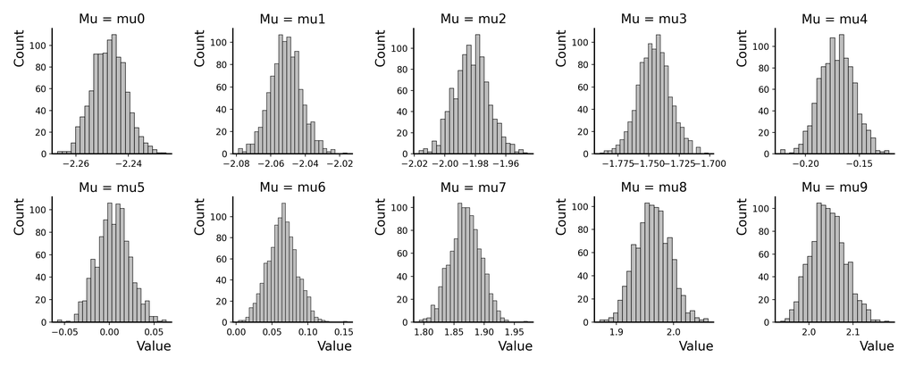

```python
plot_means(res)
```

# Infinite latent feature models

In statistical analysis, we a frequently interested in decomposing data into a small number of components. Latent feature models decompose a data set $Y$ into a binary matrix $Z$ and a matrix of loadings $\Psi$

$$\begin{equation}
Y = Z \Psi + \epsilon
\end{equation}$$

where $\epsilon$ is a Gaussian noise matrix. Nonparametric factor models implement a observation model that consists of infinitely many features $K=\infty$. Using the stick-breaking construction of a Indian buffet process (Ghosal and Van der Vaart (2017), Doshi et al. (2009), Teh, Grür, and Ghahramani (2007), Paisley and Carin (2009)), we will explore fitting the following generative model using variational inference

$$\begin{align}
\beta & \sim \text{Gamma}(1.0, 1.0) \\
\nu_k & \sim\text{Beta}(1.0, \beta) \\
\pi_k & = \prod_{j=1}^{k} \nu_j \\
z_{ik} & \sim \text{Bernoulli}(\pi_k)\\
\Psi & \sim \text{MatrixNormal}(0, I, I) \\
\sigma_k & \sim \text{Normal}^+(1.0) \\
y_i & \sim \text{MvNormal}(z_i^T \Psi, \sigma_k I)
\end{align}$$

where we again truncate $K$ to a sufficiently high value.

## Data

As above, we simulate some artificial data for inference. We’ll simulate data with $Q=10$ dimensions and a latent dimensionality of $K=5$.

```python
n_samples = 100
K = 5
Q = 10
```

Next we simulate the probabilities that a latent feature is active and the binary feature matrix itself.

```python
nu = dist.Beta(5.0, 1.0).sample(random.PRNGKey(0), sample_shape=(K,))
pi = np.cumprod(nu)

Z = dist.Bernoulli(probs=pi).sample(
  random.PRNGKey(1),
  sample_shape=(n_samples,)
)
```

The binary feature matrix is shown below.

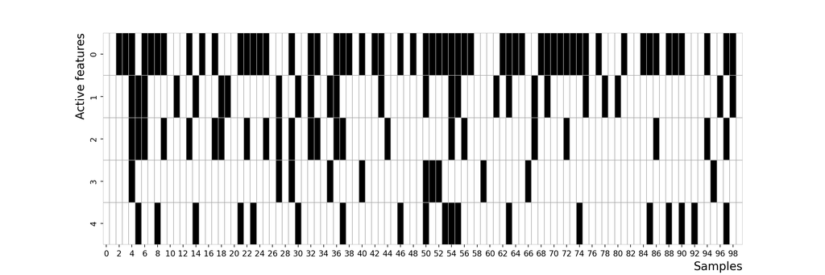

```python
_ = plt.figure(figsize=(15, 5))
ax = sns.heatmap(
    Z.T,
    linewidths=0.1,
    cbar=False,
    cmap=["white", "black"],
    linecolor="darkgrey",
)
ax.set_ylabel("Active features")
ax.set_xlabel("Samples")
ax.minorticks_off()
plt.show()
```

We finally simulate the actual data

```python
psi = dist.Normal().sample(
  random.PRNGKey(0),
  sample_shape=(K, Q)
)
eps = dist.Normal(0.0, 0.1).sample(
  random.PRNGKey(0),
  sample_shape=(n_samples, Q)
)
y = Z @ psi + eps
```

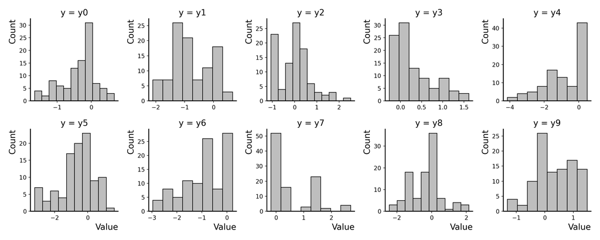

```python
df = pd.DataFrame(y, columns=[f"y{i}" for i in range(Q)])
df = df.melt(var_name="y", value_name="Value")

_ = plt.figure(figsize=(10, 4))
g = sns.FacetGrid(
  df,
  col="y",
  col_wrap=5,
  sharex=False,
  sharey=False
)
_ = g.map_dataframe(
  sns.histplot,
  x="Value",
  color="darkgrey"
)
plt.show()
```

## Model

```python
temperature = 0.000001
rec_temperature = np.reciprocal(temperature)

def prior():
    nu = numpyro.sample("nu", dist.Beta(np.ones(K), 1.0))
    pi = numpyro.deterministic("pi", np.cumprod(nu))

    Z = numpyro.sample(
        "Z",
        tfp_jax.RelaxedBernoulli(temperature, probs=pi),
        sample_shape=(n_samples,),
    )

    psi = numpyro.sample("psi", dist.Normal(np.zeros((K, Q)), 1.0))
    sigma = numpyro.sample("sigma", dist.HalfNormal(np.ones(Q)))

    return nu, pi, Z, psi, sigma
```

We implement the log likelihood again as a separate function to be able to easily check the code:

```python
def log_likelihood(y, pi, Z, psi, sigma):
    mean = Z @ psi
    lpdf = dist.Independent(
        dist.Normal(loc=mean, scale=sigma), reinterpreted_batch_ndims=1
    ).log_prob(y)

    return np.sum(lpdf)
```

The actual NumPyro model consists of the prior model and a factor that increments the log-density via a `factor`:

```python
def model():
    _, pi, Z, psi, sigma = prior()
    numpyro.factor("log_likelihood", log_likelihood(y, pi, Z, psi, sigma))
```

We approximate the posterior distributions again using mean field variational inference again which requires us to place surrogates over each latent variable. We use the following guides, adopting from Doshi et al. (2009)

$$\begin{align}
q_{\lambda}(\beta) & = \text{Gamma}(\lambda_{\beta_0}, \lambda_{\beta_1}) \\
q_{\lambda}(\nu_k) & = \text{Beta}(\lambda_{\nu_{k0}}, \lambda_{\nu_{k1}})\\
q_{\lambda}(z_{ik}) & = \text{RelaxedBernoulli}(\lambda_{z_{ik}})\\
q_{\lambda}(\Psi) & = \text{MatrixNormal}\left(\lambda_{\Psi_{0}}, I, \text{diag}(\lambda_{\Psi_{1}})\right)
q_{\lambda}(\sigma_k) & = \text{Normal}^+(\lambda_{\sigma_{k}})\\
\end{align}$$

where we constraint the scale parameters to be positive.

```python
def guide():
    q_nu_concentration1 = numpyro.param(
        "nu_concentration1",
        init_value=np.ones(K),
        constraint=constraints.positive,
    )
    q_nu_concentration0 = numpyro.param(
        "nu_concentration0",
        init_value=np.ones(K) * 2.0,
        constraint=constraints.positive,
    )
    q_nu = numpyro.sample(
        "nu",
        dist.Beta(
            concentration1=q_nu_concentration1,
            concentration0=q_nu_concentration0,
        ),
    )

    z_logits = numpyro.param(
        "z_logits",
        init_value=np.tile(np.linspace(3.0, -3.0, K), (n_samples, 1))
    )
    Z = numpyro.sample(
        "Z",
        dist.TransformedDistribution(
            dist.Logistic(z_logits * rec_temperature, rec_temperature),
            dist.transforms.SigmoidTransform(),
        ),
    )

    q_psi_mu = numpyro.param("psi_mu", init_value=np.zeros((K, Q)))
    q_psi_sd = numpyro.param(
        "psi_sd",
        init_value=np.ones((K, Q)),
        constraint=constraints.positive,
    )
    psi = numpyro.sample(
      "psi",
      dist.Normal(q_psi_mu, q_psi_sd)
    )

    q_sigma_scale = numpyro.param(
        "sigma_scale",
        init_value=np.ones(Q),
        constrain=constraints.positive
    )
    q_sigma = numpyro.sample(
      "sigma",
      dist.HalfNormal(scale=q_sigma_scale)
    )
```

## Inference

We use NumPyro again for fitting the variational parameters.

```python
adam = optim.Adam(0.01)
svi = SVI(model, guide, adam, loss=TraceGraph_ELBO(20))
res = svi.run(random.PRNGKey(1), num_steps=20, progress_bar=False)
```

Let’s have a look at the losses

```python
res.losses
```

```
DeviceArray([1.1301213e+09, 1.1504045e+09, 1.1392201e+09, 1.1388653e+09,
             1.1287686e+09, 1.1279396e+09, 1.1238774e+09, 1.1299400e+09,
             1.1204029e+09, 1.1143971e+09, 1.1224852e+09, 1.1138432e+09,
             1.1067560e+09, 1.0981290e+09, 1.0948013e+09, 1.0969151e+09,
             1.1256913e+09, 1.0993952e+09, 1.0882021e+09, 1.0954578e+09],            dtype=float32)
```

Next we check out the means of the variational posterior of $\Psi$

```python
res.params["psi_mu"]
```

```
DeviceArray([[-0.05537366, -0.05789718, -0.04207291, -0.03636777,
              -0.0792802 ,  0.06957835, -0.10198555,  0.04545656,
              -0.04863525,  0.04957656],
             [-0.04581999, -0.09344805, -0.03657955, -0.03603495,
              -0.06516565,  0.06936485, -0.0912144 ,  0.04541943,
              -0.0495175 ,  0.05069289],
             [-0.03413232, -0.00024751, -0.07176095,  0.00873105,
              -0.07885628,  0.07182958, -0.10417484,  0.04564859,
              -0.05006231,  0.06351136],
             [-0.07189159, -0.01034306, -0.06488634, -0.02970389,
               0.02645468,  0.00543227, -0.0508515 ,  0.04278465,
              -0.0302923 ,  0.08615799],
             [ 0.00297804, -0.08187226,  0.00409959, -0.06895491,
              -0.00026204,  0.06763739, -0.07308418,  0.0678682 ,
              -0.05548359,  0.05235263]], dtype=float32)
```

In comparison, these are the real features:

```python
psi
```

```
DeviceArray([[-1.94963470e-01, -1.22714722e+00, -9.17790174e-01,
               1.45208761e-01,  1.81499321e-03, -7.49587119e-01,
              -8.02633405e-01,  1.22428991e-01, -1.75890237e-01,
               1.05807412e+00],
             [-2.44926229e-01, -7.76450038e-01,  4.07351792e-01,
               5.34739316e-01, -1.35932589e+00, -2.18004417e+00,
              -2.71964520e-01,  1.36571479e+00,  3.09982032e-01,
               3.47223938e-01],
             [-3.68758589e-01,  2.74834096e-01,  1.21677899e+00,
              -2.98193663e-01, -1.75672746e+00,  1.55728388e+00,
              -5.27756453e-01,  1.29978344e-01, -1.28797793e+00,
              -1.37600648e+00],
             [ 5.84051490e-01,  4.58686858e-01,  4.16815877e-02,
              -5.97279407e-02,  3.07540983e-01,  1.64558426e-01,
              -5.24744838e-02,  1.16775799e+00,  1.72148609e+00,
               3.67930353e-01],
             [-9.40788090e-01, -1.12068936e-01,  7.24384964e-01,
               9.10822451e-01, -9.77851212e-01, -3.19997132e-01,
              -1.42063260e+00, -1.03271484e-01, -8.78654420e-01,
              -3.93549502e-01]], dtype=float32)
```

# License

The notebook is licensed under a [Creative Commons Attribution-NonCommercial 4.0 International License](http://creativecommons.org/licenses/by-nc/4.0/).

# References

Blei, David M, and Michael I Jordan. 2006. “Variational Inference for Dirichlet Process Mixtures.” *Bayesian Analysis* 1 (1): 121–43.

Doshi, Finale, Kurt Miller, Jurgen Van Gael, and Yee Whye Teh. 2009. “Variational Inference for the Indian Buffet Process.” In *Artificial Intelligence and Statistics*, 137–44. PMLR.

Ghosal, Subhashis, and Aad Van der Vaart. 2017. *Fundamentals of Nonparametric Bayesian Inference*. Vol. 44. Cambridge University Press.

Hoffman, Matthew D, David M Blei, Chong Wang, and John Paisley. 2013. “Stochastic Variational Inference.” *Journal of Machine Learning Research* 14 (5).

Jang, Eric, Shixiang Gu, and Ben Poole. 2016. “Categorical Reparameterization with Gumbel-Softmax.” *arXiv Preprint arXiv:1611.01144*.

Maddison, Chris J, Andriy Mnih, and Yee Whye Teh. 2016. “The Concrete Distribution: A Continuous Relaxation of Discrete Random Variables.” *arXiv Preprint arXiv:1611.00712*.

Paisley, John, and Lawrence Carin. 2009. “Nonparametric Factor Analysis with Beta Process Priors.” In *Proceedings of the 26th Annual International Conference on Machine Learning*, 777–84.

Teh, Yee Whye, Dilan Grür, and Zoubin Ghahramani. 2007. “Stick-Breaking Construction for the Indian Buffet Process.” In *Artificial Intelligence and Statistics*, 556–63. PMLR.